# Modeling and prediction for movies

A quick check is done to see if the remaining conditions are met as well.

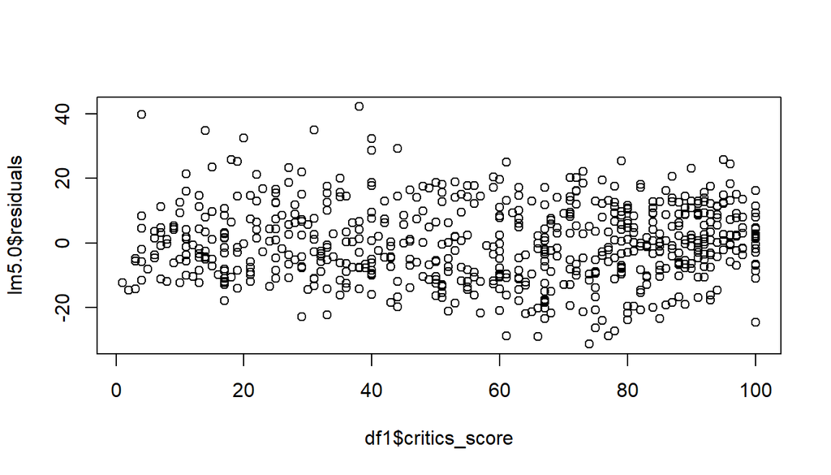

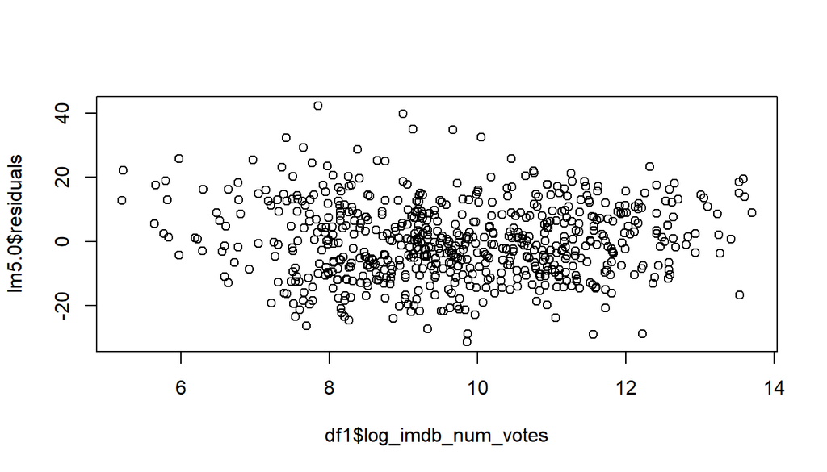

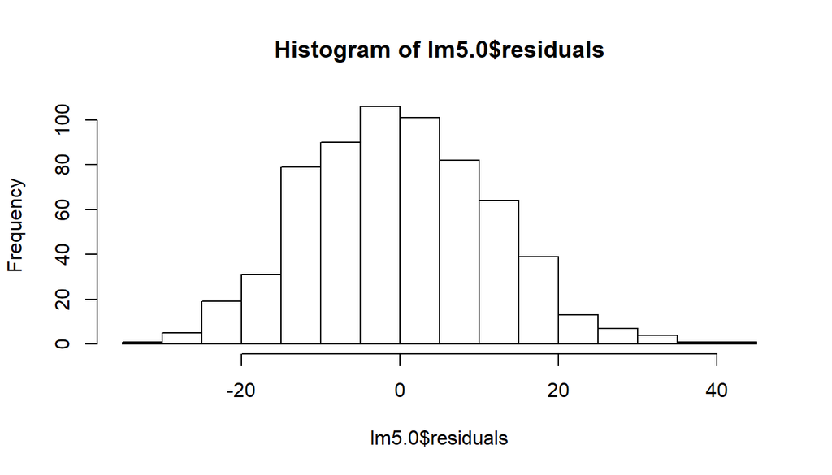

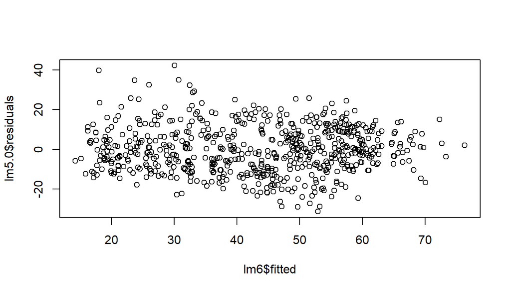

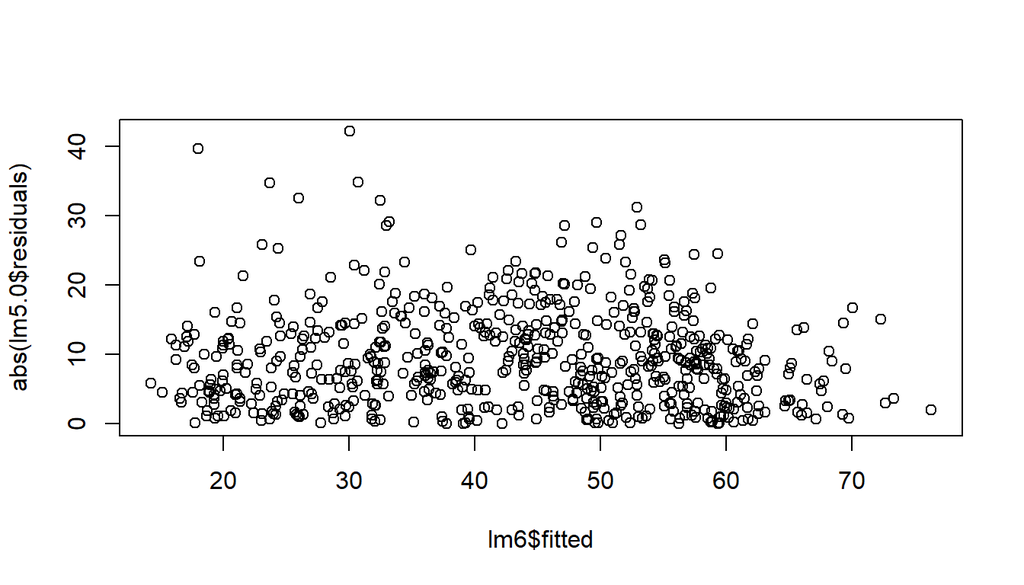

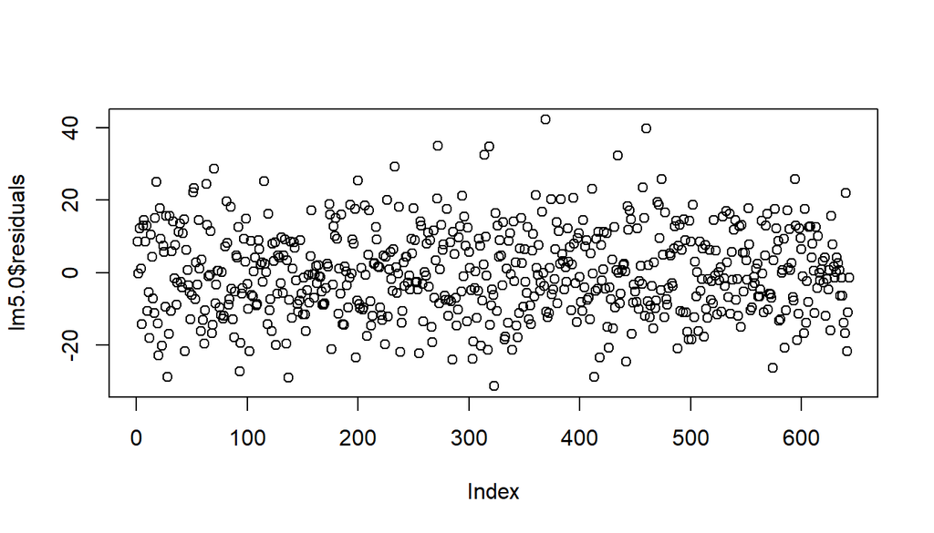

From the above plot it is clear that all the conditions are met and hence the model fits the dataset.

## Part 5.2: Prediction

```
##
## Call:
## lm(formula = (popularity_rating)^2 ~ critics_score + studio_rating +
##     thtr_rel_season + log_imdb_num_votes + best_pic_nom + best_actor_win,
##     data = df1)
##
## Residuals:
##     Min      1Q  Median      3Q     Max
## -31.286  -8.489  -0.485   8.482  42.216
##
## Coefficients:
##                       Estimate Std. Error t value Pr(>|t|)
## (Intercept)             1.5664     3.0194   0.519  0.60408
## critics_score           0.4628     0.0172  26.913  < 2e-16 ***
## studio_ratingTop 10    -2.5456     1.3326  -1.910  0.05655 .
## studio_ratingTop 5     -0.7064     1.1016  -0.641  0.52161
## thtr_rel_seasonSpring  -1.1232     1.3548  -0.829  0.40739
## thtr_rel_seasonSummer  -1.7539     1.3143  -1.334  0.18253
## thtr_rel_seasonWinter   1.1220     1.2885   0.871  0.38418
## log_imdb_num_votes      1.6202     0.3008   5.387 1.01e-07 ***
## best_pic_nomyes         7.2266     2.7283   2.649  0.00828 **
## best_actor_winyes      -1.8940     1.3780  -1.374  0.16978
## ---
## Signif. codes:  0 '***' 0.001 '**' 0.01 '*' 0.05 '.' 0.1 ' ' 1
##
## Residual standard error: 11.8 on 633 degrees of freedom
## Multiple R-squared:  0.5927, Adjusted R-squared:  0.5869
## F-statistic: 102.3 on 9 and 633 DF,  p-value: < 2.2e-16
```

The equation for prediction can be summed up as:

**popularity_rating = sqrt( 1.566 + 0.463 x critics_score - 2.546 studio_rating: Top 10 - 0.706 studio_rating: Top 5 - 1.123 thtr_rel_season:Spring - 1.754 thtr_rel_season:Summer + 1.122 thtr_rel_season:Winter + 1.62 x log_imdb_num_votes + 7.227 best_pic_nom: yes - 1.894 best_actor_win:yes)**

We would test this for the movie “Black Panther” for which [imdb_rating](https://www.imdb.com/title/tt1825683/?ref_=adv_li_tt) is 7.3, released by Walt Disney on 16th Feb 2018. # of voters on IMDB is 611,125 & which was nominated & won the oscar for the best movie while none of its lead actors have ever won an oscar. The movie has a critics_rating of 96 & audience_rating of 79 on [Rotten Tomatoes](https://www.rottentomatoes.com/m/black_panther_2018). The calculated popularity_rating for this movie is 7.6.

```
##        fit     lwr    upr
## 1 8.673188 7.17133 9.9509
```

The model thus predicts that popularity_score of the movie, **Black Panther** is 8.673 (actual popularity_score = 7.6) with a 95% confidence interval of 7.17 to 9.95.

## Part 6.2: Conclusion

The observations from the study can be summarized as follows:

1. A handful of variables which includes **critics_score, studio_rating, imdb_num_votes & best_pic_nom** seem to be the significant predictors that make a movie popular.
2. Forming the Prediction model adds two more variable to the list which includes, **thtr_rel_season & best_actor_win.**
3. The **popularity_rating** of a movie is observed to be positively related to **critics_score, imdb_num_votes & best_pic_nom** as indicated by the positive slope co-efficient in the summary table.
4. The **popularity_rating** of a movie is observed to have a negative relation w.r.t. variables that included **studio_rating & best_actor_win** contrary to having a positive relationship.
1. For the variable **studio_rating**, poor categorization of the variable might be responsible for anomaly.
2. The variable **best_actor_win** right now does not differentiate between an actor who would have won several awards to an actor who has just won once. Adding this additional information would help in correcting this error.

Since this was an observational study, results from the study are non-causal in nature. The study is also affected by **volunteering bias** which comes from the audience who chose to review the movies through the IMDB & Rotten Tomatoes platform. The results can hence be generalized only to the audience & critics for these websites & not to the general population.

Including certain additional information would tend to make this study more fruitful:  
1. # of awards (not limited to oscars) won by the lead actor, actress & the director of the movie.  
2. Information on advertisement & marketing spendings for movie promotion.  
3. Information on box-office earnings. The ratio of 3 & 4 would create an interesting variable to gauge the commercial success of a movie.  
4. # of critics who voted rather than just the critics_rating for Rotten Tomatoes.  
5. Demography & gender of audience & critics who voted for the movie.